# BIOS 545 - 2019 - Lecture 8: Functions Part 2

Ziyi Li (ziyi.li@emory.edu)

### Some suggestions when writing functions

- **Keep functions short. If your function is long then split it up into different functions**
- **Functions can call other functions**
- **Keeping functions separate makes it easy to identify possible problems**
- **Try your function with a large variety of data to find possible problems**
- **Use if statements up front to catch bad input values**
- **Put comments in your code so you and others who read your code will know what you are trying to do**

<Ref: www.stat.berkeley.edu%2F~statcur%2FWorkshop2%2FPresentations%2Ffunctions.pdf>

### 1. Scoping

It is important to understand scoping rules when writing functions.

The `environment` command shows you the current environment. Normally you don’t worry about this although it is important to understand since it is linked to scope.

```r
environment()
```

```
## <environment: R_GlobalEnv>
```

```r
ls() # your current environment will look different
```

```
## character(0)
```

You can remove all variables in your current environment. This is for when you want to “clean house” and start over.

```r
rm(list=ls())
```

As proof that functions run within their own environment consider this example:

```r
environment()
```

```
## <environment: R_GlobalEnv>
```

```r
myenvfunc <- function() {
     print(environment())
}

# See what happens when we call the environment command from within
# a function
myenvfunc()
```

```
## <environment: 0x7f82b4266a98>
```

```r
# So myenvfunc runs in its OWN environment that is separate from the
# Global environment.
```

### 2. Example

#### In this example an object `x` will be defined with value zero. Inside `myfunc`, the `x` is defined with value 3. Executing the function myfunc will not affect the value of the global variable `x`.

```r
x <- 0 # Set x to zero in the global environment (your console)

myfunc <- function(x) { # Define this function
     x <- 3 # This value of "x" is private
     return(x)
}
myfunc() # Function returns 3
```

```
## [1] 3
```

```r
x # The value of x in the global env is unchanged
```

```
## [1] 0
```

This means a normal assignment within a function will not overwrite objects outside the function. An object created within a function will be lost when the function has finished.

```r
rm(list=ls()) # Clears all variables from your environment.

exampf <- function(x) {
     return(x + a)
}
ls() # The function f is in our global environment
```

```
## [1] "exampf"
```

```r
exampf(2)
```

```
## Error in exampf(2): object 'a' not found
```

When f is called it passes the value of 2. So `x` assumes a local value of 2. Then the function wants to add `x = 2` to the value that has not been specified so the function results in an error. This seems reasonable since R can’t find a variable called “a” anywhere.

```r
exampf <- function(x) {
     return(x + a)
}
a <- 10
x <- 5
ls()
```

```
## [1] "a"      "exampf" "x"
```

```r
exampf(2)
```

```
## [1] 12
```

When exampf is called, the local binding of `x <- 2` shadows the global binding `x <- 5`. The variable a is a free variable in the frame of the function call, and so the global binding `a <- 10` applies.

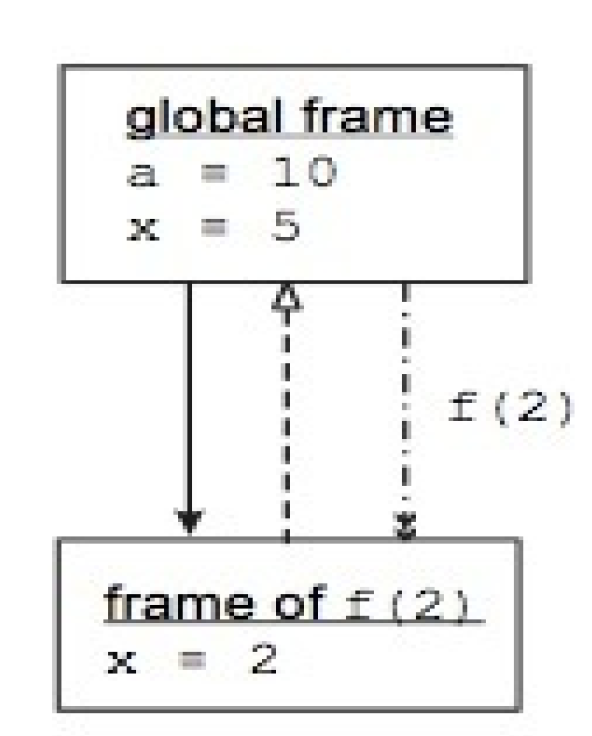

```r
a <- 10
x <- 5
f <- function(x) {
     a <- 5
     g(x)
}

g <- function(y) {
     return(y + a)
}

f(2)
```

```
## [1] 12
```

In R, the global binding `a <- 10` is used when f calls g, because a is a free variable in g, and g is defined at the command prompt in the global frame.

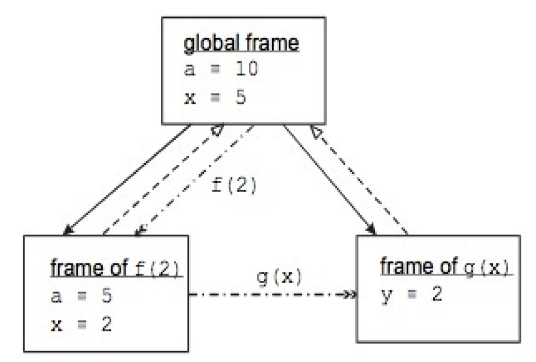

```r
a <- 10; x <- 5
f <- function(x) {
     a <- 5
     g <- function(y) {
          return(y + a)
     }
     g(x)
}
f(2)
```

```
## [1] 7
```

The local function `g` is defined within function f so the environment of `g` comprises the local frame of `g` followed by the environment of `f`. Because `a` is a free variable in `g`, the interpreter next looks for a value for `a` in the local frame of `f`; it finds the value `a <- 5`, which shadows the global binding `a <- 10`

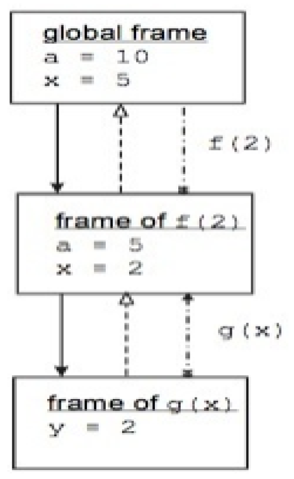

### What does this all mean ?

- **The arguments and variables that you use within a function are private to that function even if you use the same name as a previously defined variable**
- **It is a common mistake to refer to a variable within a function without initializing it to something first. If it has the same name as a variable in the “global environment” then it will pick up that variable’s value**
- **So make sure you keep track of what you are doing within your function**
- **Use descriptive and unambiguous variable names**

#### Use descriptive and unambiguous variable names

```r
exampf <- function(x) {
     a <- 3
     return(x + a)
}

# Maybe do something like:
exampf <- function(exampx) {
     exampa <- 3
     return(exampx + exampa)
}

# -OR
exampf <- function(exampx, exampa) {
     return(exampx + exampa)
}
```

#### Functions can always call other functions that exist within the same environment. It happens all the time and is one of the more common activities in R

```r
exampf <- function(myvec) {
     retval <- c(mean(myvec), sd(myvec)) # mean and sd are known
     return(retval)
}

exampf(1:10)
```

```
## [1] 5.50000 3.02765
```

#### This includes any functions that you have written too. Define this function within RStudio either at the console or from the edit window.

#### It is now in your “Global Environment” and can be used at the prompt or by other functions that you might write

```r
is.odd <- function(somenumber) {
     retval <- 0
     if (somenumber %% 2 != 0) {
          retval <- TRUE
     } else {
          retval <- FALSE
     }
     return(retval)
}

is.odd(3)
```

```
## [1] TRUE
```

#### Let’s say we are writing a function to compute the median of a vector. We’ll need to determine if its length is even or odd so we could use the `is.odd` function to help us out here

```r
mymedian <- function(medianvec) {
     # Function to compute the median of a vector
     medianveclength = length(medianvec)

     if (is.odd(medianveclength)) { # is.odd is available for use
          # We find the median using the formula for odd length vectors
     } else {
          # We find the median using the formula for even length vectors
     }
}
```

Or, alternatively, we could define the `is.odd` function within the `mymedian` function although this means that `is.odd` would be available only to the `mymedian` function

```r
mymedian <- function(medianvec) {
     is.odd <- function(somenumber) { # We define is.odd inside of mymedian
          retval <- 0
          if (somenumber %% 2 != 0) {
             retval <- TRUE
          } else {
              retval <- FALSE
          }
          return(retval)
     }

     # Function to compute the median of a vector
     medianveclength <- length(medianvec)
     if (is.odd(medianveclength)) {
          # We find the median using the formula for odd length vectors
     } else {
          # We find the median using the formula for even length vectors
     }
}
```

### 3. Arguments

#### “a” and “b” represent arguments that correspond to sides a and b, respectively. We compute “c” the hypoteneuse and return its value.

```r
pythag <- function(a = 4, b = 5) {
     if (!is.numeric(a) | !is.numeric(b)) {
          stop("I need real values to make this work")
     }
     hypo <- sqrt(a^2 + b^2)
     myreturnlist <- list(hypoteneuse = hypo, sidea = a, sideb = b)
     return(myreturnlist)
}

pythag(4,5) # 4 is matched to a and 5 is matched to b
```

```
## $hypoteneuse
## [1] 6.403124
##
## $sidea
## [1] 4
##
## $sideb
## [1] 5
```

```r
pythag(5,4) # 5 is matched to a
```

```
## $hypoteneuse
## [1] 6.403124
##
## $sidea
## [1] 5
##
## $sideb
## [1] 4
```

```r
pythag(b=4,a=5) # 5 is matched to a
```

```
## $hypoteneuse
## [1] 6.403124
##
## $sidea
## [1] 5
##
## $sideb
## [1] 4
```

#### Look at the help page for the `mean` function

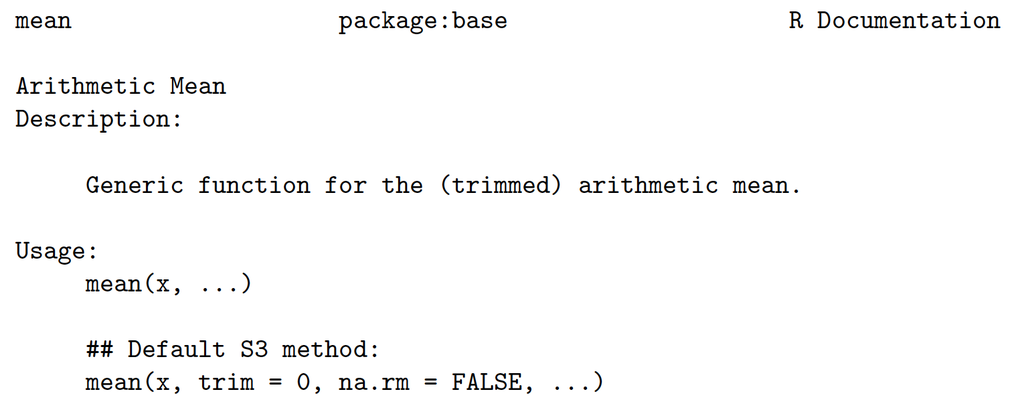

#### The `mean()` function has three arguments:

`x`: a value or vector to take the mean of `trim`: a value that let’s you trim the vector by `na.rm`: ignore missing values

```r
set.seed(1)
myx <- rnorm(20)
mean(myx) # myx MATCHES the "x" argument
```

```
## [1] 0.1905239
```

```r
mean(myx,0.05) # myx MATCHES "x" and 0.05 MATCHES "trim"
```

```
## [1] 0.2461054
```

```r
# myx MATCHES "x", 0.05 MATCHES "trim", TRUE matches na.rm
mean(myx,0.05,TRUE)
```

```
## [1] 0.2461054
```

#### We could explicitly name the arguments as we provide them. This way, R will never be confused about what value corresponds to what argument

```r
set.seed(1)

mean(x = myx, trim = 0.05, na.rm = TRUE)
```

```
## [1] 0.2461054
```

```r
# As long as you name the arguments you type them in any order
mean(trim = 0.05, na.rm = TRUE, x = myx)
```

```
## [1] 0.2461054
```

```r
# BUT THE FOLLOWING WON'T WORK !
mean(TRUE,0.05,myx)
```

```
## [1] 1
```

### Hints about arguments:

- **Use named arguments especially in cases where there is a long list of arguments**
- **If you use named arguments then you don’t have to remember the position of the arguments.**
- **Check out the plot command, which has way too many options for anyone to reasonably remember (well most people anyway)**
- **There is no convenient way to remember the arguments by position unless you have a photographic memory.**

Let’s take another look at the help page for the mean function:

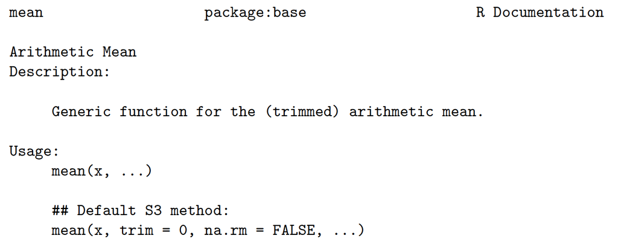

### What is the “…” argument?

- **We can pass an unspecified number of parameters to a function by using the … notation in the argument list**
- **This is usually done when you want to give the user the option of passing any number of arguments that are intended for another function**

#### Suppose you write a small function to do some plotting. You want to hard code in the color red for all plots. That is you want to force the color red on anyone who uses your function (not nice but this is just an example)

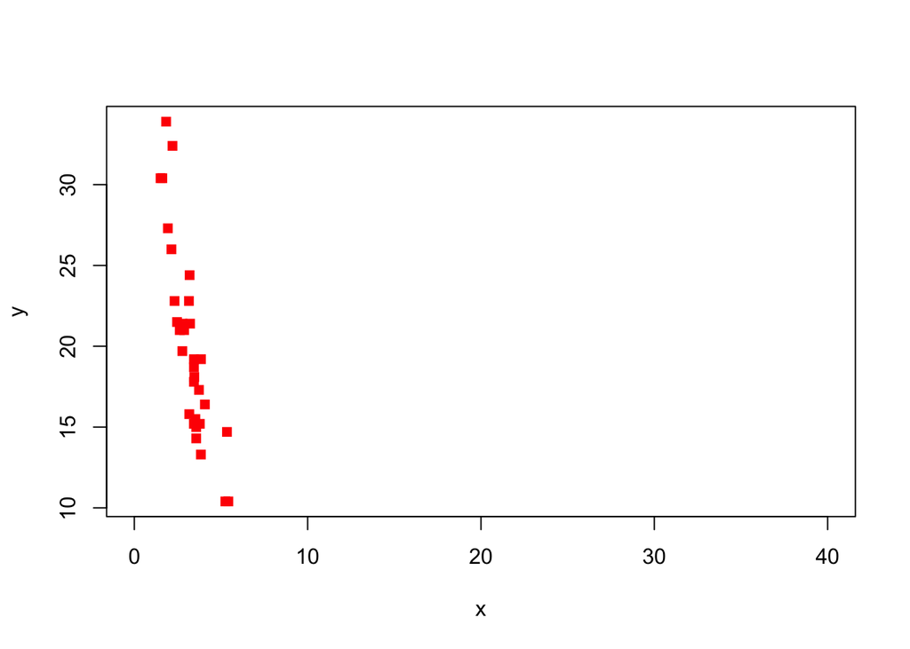

```r
my.plot <- function(x,y, ...) {
     plot(x,y, col="red",...)
}

my.plot(x=mtcars$wt, y=mtcars$mpg, pch=15, lty=2, xlim=c(0,40))
```